# Exploring Physical Fitness Patterns

# 4 PCA and Clustering Analysis

## 4.1 Pairwise Relationships

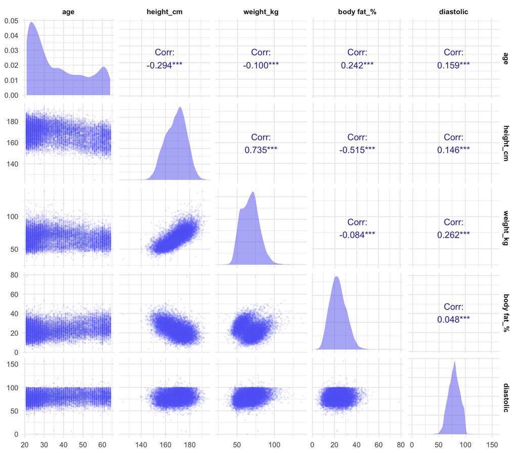

Figure 4. GGally pairwise plot of the five variables used in PCA (age, height, weight, body fat, diastolic BP).

```r
scaled_data <- bodyPerformance %>%
  select(where(is.numeric)) %>%
  select(1:min(5, ncol(.)))

GGally::ggpairs(
  scaled_data,
  upper = list(continuous = wrap("cor", size = 3.5, color = "#3730a3")),
  lower = list(continuous = wrap("points", alpha = 0.08, size = 0.4,
                                  color = "#6366f1")),
  diag  = list(continuous = wrap("densityDiag", fill = "#6366f1",
                                   alpha = 0.5, color = NA))
) +
  theme_minimal(base_size = 10) +
  theme(strip.text = element_text(face = "bold", size = 8))
```

Table 3. Pairwise relationships from GGally correlation matrix.

Variable Pair

Correlation

Direction

Interpretation

Height vs Weight

r = 0.735

Strong positive - taller individuals tend to weigh more

Height vs Body Fat %

r = −0.515

−

Moderate negative - taller individuals generally carry less body fat

Age vs Height

r = −0.294

−

Older participants tend to be slightly shorter on average

Age vs Body Fat %

r = 0.242

Body fat increases modestly with age

Weight vs Body Fat %

r = −0.084

−

Weak - weight alone does not strongly predict body fat % in this group

Weight vs Diastolic

r = 0.262

Moderate positive - heavier individuals may have slightly higher diastolic BP

Age vs Diastolic

r = 0.159

Small positive - diastolic BP rises slightly with age